# Lab 7 --- Module4

## Applied NLP

### Lab 7 --- Module 4

### Instructions on how to submit your work on Canvas

To convert your Notebook to an HTML file, follow these steps:

- Open the Notebook that you want to convert to an HTML file.
- Ensure that the notebook is saved with the latest changes.
- In the Notebook interface, navigate to File in the menu bar.
- Click on Download as and select HTML (.html) from the dropdown menu. This will initiate the conversion process.
- The Jupyter Notebook will be converted to an HTML file and automatically downloaded to the default download location on your computer.
- Locate the downloaded HTML file on your computer and verify that the conversion was successful.
- Optionally, open the HTML file in a web browser to view and verify the content.
- Upload your HTML file on Canvas.

Make sure to save your Notebook before attempting to convert it to an HTML file.

### Exercise 1 Text Classification using CNNs (Convolutional Neural Networks)

In this lab, you will work on a text classification task using Convolutional Neural Networks (CNNs). Instead of traditional NLP techniques, you will build a neural network model to classify social media posts into "sexist" and "non-sexist" categories. CNNs are effective for extracting hierarchical patterns from sequences like text data.

**Question 1 (1 point): Load and Explore the Dataset**

- Import the required libraries, including TensorFlow and Keras.
- Load the EXIST 2021 dataset into a pandas DataFrame.
- Preprocess the text data by tokenizing, removing from the dataset the non-English social media posts, padding, and converting it to sequences for compatibility with CNNs.

```python
import os
import sys
import numpy as np


#pre-processing of text
import string
import re

import pandas as pd #to work with csv files
from tensorflow.keras.preprocessing.text import Tokenizer
from tensorflow.keras.preprocessing.sequence import pad_sequences
from tensorflow.keras.utils import to_categorical
from tensorflow.keras.layers import Dense, Input, GlobalMaxPooling1D, Dropout
from tensorflow.keras.layers import Conv1D, MaxPooling1D, Embedding, LSTM
from tensorflow.keras.models import Sequential
from tensorflow.keras.initializers import Constant

from nltk import word_tokenize, pos_tag
from nltk.stem import WordNetLemmatizer
from nltk.corpus import wordnet
```

```python
EXIST_train = pd.read_csv('EXIST2021_training.tsv', delimiter='\t')
EXIST_train = EXIST_train[EXIST_train['language'] != 'es']
EXIST_train
```

|  | test_case | id | source | language | text | task1 | task2 |
| --- | --- | --- | --- | --- | --- | --- | --- |
| 0 | EXIST2021 | 1 | twitter | en | She calls herself "anti-feminazi" how about sh... | sexist | ideological-inequality |
| 1 | EXIST2021 | 2 | twitter | en | Now, back to these women, the brave and the be... | non-sexist | non-sexist |
| 2 | EXIST2021 | 3 | twitter | en | @CurvyBandida @Xalynne_B Wow, your skirt is ve... | sexist | objectification |
| 3 | EXIST2021 | 4 | twitter | en | @AurelieGuiboud Incredible! Beautiful!But I l... | non-sexist | non-sexist |
| 4 | EXIST2021 | 5 | twitter | en | i find it extremely hard to believe that kelly... | non-sexist | non-sexist |
| ... | ... | ... | ... | ... | ... | ... | ... |
| 3431 | EXIST2021 | 3432 | twitter | en | Do you think the biggest crisis in masculinity... | sexist | objectification |
| 3432 | EXIST2021 | 3433 | twitter | en | my bank account looks like a street whore | sexist | misogyny-non-sexual-violence |
| 3433 | EXIST2021 | 3434 | twitter | en | -Lev put his hand on your upper thighs. And ru... | sexist | objectification |
| 3434 | EXIST2021 | 3435 | twitter | en | @adamm_mo I believe u can let ur wife work any... | sexist | stereotyping-dominance |
| 3435 | EXIST2021 | 3436 | twitter | en | @fiovske This already looks SO BEAUTIFUL i can... | non-sexist | non-sexist |

3436 rows × 7 columns

```python
EXIST_test = pd.read_csv('EXIST2021_test_labeled.tsv', delimiter='\t')
EXIST_test = EXIST_test[EXIST_test['language'] != 'es']
EXIST_test
```

|  | test_case | id | source | language | text | task1 | task2 |
| --- | --- | --- | --- | --- | --- | --- | --- |
| 0 | EXIST2021 | 6978 | gab | en | Pennsylvania State Rep horrifies with opening ... | non-sexist | non-sexist |
| 1 | EXIST2021 | 6979 | twitter | en | @iilovegrapes He sounds like as ass, and very ... | non-sexist | non-sexist |
| 2 | EXIST2021 | 6980 | twitter | en | @averyangryskel1 @4ARealistParty LOL! "This be... | sexist | ideological-inequality |
| 3 | EXIST2021 | 6981 | twitter | en | @WanderOrange @stalliontwink Rights?I mean yea... | sexist | ideological-inequality |
| 4 | EXIST2021 | 6982 | twitter | en | the jack manifold appreciation i’m seeing is o... | non-sexist | non-sexist |
| ... | ... | ... | ... | ... | ... | ... | ... |
| 2203 | EXIST2021 | 9181 | twitter | en | @Hazel08539106 @hatterme123 @lilhazelnuttt You... | non-sexist | non-sexist |
| 2204 | EXIST2021 | 9182 | twitter | en | how are you, a grown ass woman that’s literall... | non-sexist | non-sexist |
| 2205 | EXIST2021 | 9183 | gab | en | Another gold digger looking to make money off ... | sexist | stereotyping-dominance |
| 2206 | EXIST2021 | 9184 | twitter | en | We have another first!! So glad to see women d... | non-sexist | non-sexist |
| 2207 | EXIST2021 | 9185 | twitter | en | When Simps &amp; Beta can run system &amp; be ... | sexist | ideological-inequality |

2208 rows × 7 columns

```python
def clean_text(str_list, lemmatize=True):
    clean_list = []

    for text in str_list:
        # Remove pound sign from hashtags
        text = re.sub(r'#', '', text)
        words = word_tokenize(text)
        clean_words = []

        lemmatizer = WordNetLemmatizer()  # Move lemmatizer initialization outside the loop

        for word in words:
            # Drop words with fewer than 2 characters and drop any punctuation "words"
            if len(word) > 1 and re.match(r'^\w+$', word):
                if lemmatize:
                    word = lemmatizer.lemmatize(word)  # Apply lemmatization
                clean_words.append(word)

        clean_text = ' '.join(clean_words)
        clean_list.append(clean_text)

    return clean_list
```

```python
EXIST_train['clean_text'] = clean_text(EXIST_train['text'])
EXIST_test['clean_text'] = clean_text(EXIST_test['text'])
EXIST_train['clean_text'] = EXIST_train['clean_text'].str.lower()
EXIST_test['clean_text'] = EXIST_test['clean_text'].str.lower()
EXIST_train
```

|  | test_case | id | source | language | text | task1 | task2 | clean_text |
| --- | --- | --- | --- | --- | --- | --- | --- | --- |
| 0 | EXIST2021 | 1 | twitter | en | She calls herself "anti-feminazi" how about sh... | sexist | ideological-inequality | she call herself how about shut the fucking up... |
| 1 | EXIST2021 | 2 | twitter | en | Now, back to these women, the brave and the be... | non-sexist | non-sexist | now back to these woman the brave and the beau... |
| 2 | EXIST2021 | 3 | twitter | en | @CurvyBandida @Xalynne_B Wow, your skirt is ve... | sexist | objectification | curvybandida xalynne_b wow your skirt is very ... |
| 3 | EXIST2021 | 4 | twitter | en | @AurelieGuiboud Incredible! Beautiful!But I l... | non-sexist | non-sexist | aurelieguiboud incredible beautiful but laughe... |
| 4 | EXIST2021 | 5 | twitter | en | i find it extremely hard to believe that kelly... | non-sexist | non-sexist | find it extremely hard to believe that kelly o... |
| ... | ... | ... | ... | ... | ... | ... | ... | ... |
| 3431 | EXIST2021 | 3432 | twitter | en | Do you think the biggest crisis in masculinity... | sexist | objectification | do you think the biggest crisis in masculinity... |
| 3432 | EXIST2021 | 3433 | twitter | en | my bank account looks like a street whore | sexist | misogyny-non-sexual-violence | my bank account look like street whore |
| 3433 | EXIST2021 | 3434 | twitter | en | -Lev put his hand on your upper thighs. And ru... | sexist | objectification | put his hand on your upper thigh and rubbed ci... |
| 3434 | EXIST2021 | 3435 | twitter | en | @adamm_mo I believe u can let ur wife work any... | sexist | stereotyping-dominance | adamm_mo believe can let ur wife work anywhere... |
| 3435 | EXIST2021 | 3436 | twitter | en | @fiovske This already looks SO BEAUTIFUL i can... | non-sexist | non-sexist | fiovske this already look so beautiful ca wait |

3436 rows × 8 columns

```python
EXIST_test
```

|  | test_case | id | source | language | text | task1 | task2 | clean_text |
| --- | --- | --- | --- | --- | --- | --- | --- | --- |
| 0 | EXIST2021 | 6978 | gab | en | Pennsylvania State Rep horrifies with opening ... | non-sexist | non-sexist | pennsylvania state rep horrifies with opening ... |
| 1 | EXIST2021 | 6979 | twitter | en | @iilovegrapes He sounds like as ass, and very ... | non-sexist | non-sexist | iilovegrapes he sound like a as and very conde... |
| 2 | EXIST2021 | 6980 | twitter | en | @averyangryskel1 @4ARealistParty LOL! "This be... | sexist | ideological-inequality | averyangryskel1 4arealistparty lol this behavi... |
| 3 | EXIST2021 | 6981 | twitter | en | @WanderOrange @stalliontwink Rights?I mean yea... | sexist | ideological-inequality | wanderorange stalliontwink rights mean yeah mo... |
| 4 | EXIST2021 | 6982 | twitter | en | the jack manifold appreciation i’m seeing is o... | non-sexist | non-sexist | the jack manifold appreciation seeing is on my... |
| ... | ... | ... | ... | ... | ... | ... | ... | ... |
| 2203 | EXIST2021 | 9181 | twitter | en | @Hazel08539106 @hatterme123 @lilhazelnuttt You... | non-sexist | non-sexist | hazel08539106 hatterme123 lilhazelnuttt you di... |
| 2204 | EXIST2021 | 9182 | twitter | en | how are you, a grown ass woman that’s literall... | non-sexist | non-sexist | how are you grown as woman that literally olde... |
| 2205 | EXIST2021 | 9183 | gab | en | Another gold digger looking to make money off ... | sexist | stereotyping-dominance | another gold digger looking to make money off ... |
| 2206 | EXIST2021 | 9184 | twitter | en | We have another first!! So glad to see women d... | non-sexist | non-sexist | we have another first so glad to see woman doi... |
| 2207 | EXIST2021 | 9185 | twitter | en | When Simps &amp; Beta can run system &amp; be ... | sexist | ideological-inequality | when simps amp beta can run system amp be slav... |

2208 rows × 8 columns

```python
train_labels = EXIST_train['task1']
test_labels = EXIST_test['task1']

train_texts = EXIST_train['clean_text']
test_texts = EXIST_test['clean_text']

labels_index = {'fake':1, 'real':0}

#Just to see how the data looks like.
print(train_texts[0])
print(train_labels[0])
print(test_texts[0])
print(test_labels[0])
```

```
she call herself how about shut the fucking up on your vile commentary on an elderly responsible citizen tu sach muuch ghani hai bey http
sexist
pennsylvania state rep horrifies with opening prayermooslime politican movita offended by the word and mainly christian country praying to what scandal it the mooslime strategy playing the victim card and make
non-sexist
```

```python
# Replace entries 'real' and 'fake' with values 0 and 1
train_labels = train_labels.replace(to_replace=['non-sexist', 'sexist'], value=[0, 1])
test_labels = test_labels.replace(to_replace=['non-sexist', 'sexist'], value=[0, 1])
```

```python
BASE_DIR = os.getcwd()
GLOVE_DIR = os.path.join(BASE_DIR, 'glove.6B') #download from: https://nlp.stanford.edu/projects/glove/

MAX_SEQUENCE_LENGTH = 500
MAX_NUM_WORDS = 20000
EMBEDDING_DIM = 100
VALIDATION_SPLIT = 0.2
```

```python
#Vectorize these text samples into a 2D integer tensor using Keras Tokenizer
#Tokenizer is fit on training data only, and that is used to tokenize both train and test data.
tokenizer = Tokenizer(num_words=MAX_NUM_WORDS)
tokenizer.fit_on_texts(train_texts)
train_sequences = tokenizer.texts_to_sequences(train_texts) #Converting text to a vector of word indices
test_sequences = tokenizer.texts_to_sequences(test_texts)
word_index = tokenizer.word_index
print('Found %s unique tokens.' % len(word_index))
```

```
Found 13955 unique tokens.
```

```python
#initial padding of 0s, until vector is of size MAX_SEQUENCE_LENGTH
trainvalid_data = pad_sequences(train_sequences, maxlen=MAX_SEQUENCE_LENGTH)
test_data = pad_sequences(test_sequences, maxlen=MAX_SEQUENCE_LENGTH)
trainvalid_labels = to_categorical(train_labels, num_classes = 2, dtype ="int32")
test_labels = to_categorical(test_labels, num_classes = 2, dtype ="int32")

# split the training data into a training set and a validation set
indices = np.arange(trainvalid_data.shape[0])
np.random.shuffle(indices)
trainvalid_data = trainvalid_data[indices]
trainvalid_labels = trainvalid_labels[indices]
num_validation_samples = int(VALIDATION_SPLIT * trainvalid_data.shape[0])
x_train = trainvalid_data[:-num_validation_samples]
y_train = trainvalid_labels[:-num_validation_samples]
x_val = trainvalid_data[-num_validation_samples:]
y_val = trainvalid_labels[-num_validation_samples:]
#This is the data we will use for CNN and RNN training
print('Splitting the train data into train and valid is done')
```

```
Splitting the train data into train and valid is done
```

```python
print('Preparing embedding matrix.')
# first, build index mapping words in the embeddings set
# to their embedding vector
embeddings_index = {}

with open(os.path.join(GLOVE_DIR, 'glove.6B.100d.txt'),encoding="utf8") as f:
    for line in f:
        values = line.split()
        word = values[0]
        coefs = np.asarray(values[1:], dtype='float32')
        embeddings_index[word] = coefs

print('Found %s word vectors in Glove embeddings.' % len(embeddings_index))
#print(embeddings_index["google"])

# prepare embedding matrix - rows are the words from word_index, columns are the embeddings of that word from glove.
num_words = min(MAX_NUM_WORDS, len(word_index)) + 1
embedding_matrix = np.zeros((num_words, EMBEDDING_DIM))
for word, i in word_index.items():
    if i > MAX_NUM_WORDS:
        continue
    embedding_vector = embeddings_index.get(word)
    if embedding_vector is not None:
        # words not found in embedding index will be all-zeros.
        embedding_matrix[i] = embedding_vector

# load these pre-trained word embeddings into an Embedding layer
# note that we set trainable = False so as to keep the embeddings fixed
embedding_layer = Embedding(num_words,
                            EMBEDDING_DIM,
                            embeddings_initializer=Constant(embedding_matrix),
                            input_length=MAX_SEQUENCE_LENGTH,
                            trainable=False)
print("Preparing of embedding matrix is done")
```

```
Preparing embedding matrix.
Found 400000 word vectors in Glove embeddings.
Preparing of embedding matrix is done
```

**Question 2 (1 point): Build the CNN Model**

- Import necessary layers from `Keras`, including `Embedding`, `Conv1D`, `GlobalMaxPooling1D`, and Dense.
- Build a CNN model for text classification.
- Define the model architecture, including embedding layer, convolutional layers, pooling layer, and output layer.

```python
print('Define a 1D CNN model.')

cnnmodel = Sequential()
cnnmodel.add(embedding_layer)
cnnmodel.add(Conv1D(128, 5, activation='relu'))
cnnmodel.add(MaxPooling1D(5))
cnnmodel.add(Dropout(0.25))
cnnmodel.add(Conv1D(128, 5, activation='relu'))
cnnmodel.add(MaxPooling1D(5))
cnnmodel.add(Dropout(0.25))
cnnmodel.add(Conv1D(128, 5, activation='relu'))
cnnmodel.add(GlobalMaxPooling1D())
cnnmodel.add(Dense(128, activation='relu'))
cnnmodel.add(Dropout(0.25))
cnnmodel.add(Dense(len(labels_index), activation='softmax'))

cnnmodel.compile(loss='categorical_crossentropy',
              optimizer='Adam',
              metrics=['acc'])
```

```
Define a 1D CNN model.
```

**Question 3 (1 point): Compile and Train the CNN Model**

- Compile the CNN model by specifying the optimizer, loss function, and evaluation metric.
- Split the dataset into training and testing sets.
- Train the CNN model on the training data and validate it on the testing data.
- Monitor training progress using metrics like accuracy and loss.

```python
#Train the model. Tune to validation set.
print(x_train.shape)
print(y_train.shape)
cnn_train = cnnmodel.fit(x_train, y_train,
          batch_size=16,
          epochs=3, verbose=1, validation_data=(x_val, y_val))
```

```
(2749, 500)
(2749, 2)
```

```python
score_train, acc_train = cnnmodel.evaluate(x_train, y_train)
print('Training accuracy with CNN:', acc_train)
```

```
Training accuracy with CNN: 0.7380865812301636
```

**Question 4 (1 point): Evaluate the CNN Model**

- Evaluate the trained CNN model on the testing data.
- Calculate accuracy, precision, recall, and F1-score for the classification task.
- Visualize the model's performance metrics and loss over epochs using plots.

```python
score_test, acc_test = cnnmodel.evaluate(test_data, test_labels)
print('Testing accuracy with CNN:', acc_test)
```

```
Testing accuracy with CNN: 0.6490036249160767
```

```python
from sklearn.metrics import accuracy_score, precision_score, recall_score, f1_score, confusion_matrix


# predict test y in  CNN model
predicted_labels = cnnmodel.predict(test_data)

# Convert one-hot encoded labels to class labels
true_classes = np.argmax(test_labels, axis=1)
predicted_classes = np.argmax(predicted_labels, axis=1)

# Calculate metrics
accuracy = accuracy_score(true_classes, predicted_classes)
precision = precision_score(true_classes, predicted_classes, average='weighted')
recall = recall_score(true_classes, predicted_classes, average='weighted')
f1 = f1_score(true_classes, predicted_classes, average='weighted')

# Print the metrics
print("Accuracy:", accuracy)
print("Precision:", precision)
print("Recall:", recall)
print("F1-score:", f1)
```

```
Accuracy: 0.6490036231884058
Precision: 0.6526887692595945
Recall: 0.6490036231884058
F1-score: 0.6488903705644622
```

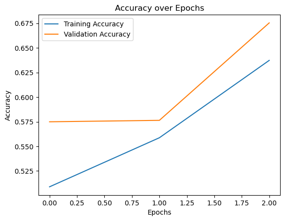

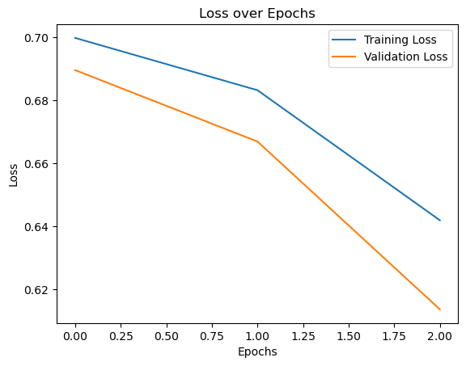

```python
import matplotlib.pyplot as plt

# Plotting accuracy over epochs
plt.plot(cnn_train.history['acc'], label='Training Accuracy')
plt.plot(cnn_train.history['val_acc'], label='Validation Accuracy')
plt.xlabel('Epochs')
plt.ylabel('Accuracy')
plt.title('Accuracy over Epochs')
plt.legend()
plt.show()

# Plotting loss over epochs
plt.plot(cnn_train.history['loss'], label='Training Loss')
plt.plot(cnn_train.history['val_loss'], label='Validation Loss')
plt.xlabel('Epochs')
plt.ylabel('Loss')
plt.title('Loss over Epochs')
plt.legend()
plt.show()
```

**Question 5 (1 point): Fine-tuning and Further Improvements**

- Experiment with different hyperparameters like filter sizes, number of filters, and pooling strategies to fine-tune the model.
- Apply techniques like dropout and batch normalization to mitigate overfitting if there exist.
- Try using pre-trained word embeddings like `Word2Vec` or `GloVe` to initialize the embedding layer.

```python
file_path = "/Users/pikaqiu/Desktop/AU /class /2024 spring/ Natural Lang Processing/Module4_Lab_Week7/glove.6B/glove.6B.100d.txt"
with open(file_path, "r", encoding="utf-8") as file:
    vocab_size = sum(1 for line in file)
print("Vocabulary size:", vocab_size)
# Example code to determine MAX_SEQUENCE_LENGTH
max_sequence_length = max(len(sequence) for sequence in EXIST_train['clean_text'])
print("Maximum sequence length:", max_sequence_length)
# Example code to determine MAX_SEQUENCE_LENGTH
max_sequence_length = max(len(sequence) for sequence in EXIST_test['clean_text'])
print("Maximum sequence length:", max_sequence_length)
```

```
Vocabulary size: 400000
Maximum sequence length: 905
Maximum sequence length: 3082
```

```python
from keras.models import Sequential
from keras.layers import Conv1D, MaxPooling1D, GlobalMaxPooling1D, Dense, Dropout, BatchNormalization

print('Define a 1D CNN model.')

# Assuming vocab_size and max_sequence_length are defined elsewhere in your code
vocab_size = 40000
max_sequence_length = 3082
embedding_dim = EMBEDDING_DIM

# Define hyperparameters
filter_sizes = [3,5,7]
num_filters = 128
pool_sizes = [3,5,7]

cnnmodel = Sequential()
cnnmodel.add(embedding_layer)  # Replacing Embedding layer with your pre-defined embedding_layer

# Experimenting with different filter sizes and numbers
for filter_size in filter_sizes:
    cnnmodel.add(Conv1D(num_filters, filter_size, activation='relu'))
    cnnmodel.add(MaxPooling1D(pool_size=pool_sizes[0]))
    cnnmodel.add(Dropout(0.5))

# Adding batch normalization to mitigate overfitting
cnnmodel.add(BatchNormalization())

# Global max pooling
cnnmodel.add(GlobalMaxPooling1D())

# Adding a fully connected layer
cnnmodel.add(Dense(128, activation='relu'))
cnnmodel.add(Dropout(0.5))

# Output layer
cnnmodel.add(Dense(len(labels_index), activation='softmax'))

# Compile the model
cnnmodel.compile(loss='categorical_crossentropy',
              optimizer='adam',
              metrics=['accuracy'])
```

```
Define a 1D CNN model.
```

```python
#Train the model. Tune to validation set.
print(x_train.shape)
print(y_train.shape)
cnn_train = cnnmodel.fit(x_train, y_train,
          batch_size=16,
          epochs=3, verbose=1, validation_data=(x_val, y_val))
score_train, acc_train = cnnmodel.evaluate(x_train, y_train)
print('Training accuracy with CNN:', acc_train)
```

```
(2749, 500)
(2749, 2)
Training accuracy with CNN: 0.5147326588630676
```

```python
score_test, acc_test = cnnmodel.evaluate(test_data, test_labels)
print('Testing accuracy with CNN:', acc_test)

from sklearn.metrics import accuracy_score, precision_score, recall_score, f1_score, confusion_matrix


# predict test y in  CNN model
predicted_labels = cnnmodel.predict(test_data)

# Convert one-hot encoded labels to class labels
true_classes = np.argmax(test_labels, axis=1)
predicted_classes = np.argmax(predicted_labels, axis=1)

# Calculate metrics
accuracy = accuracy_score(true_classes, predicted_classes)
precision = precision_score(true_classes, predicted_classes, average='weighted')
recall = recall_score(true_classes, predicted_classes, average='weighted')
f1 = f1_score(true_classes, predicted_classes, average='weighted')

# Print the metrics
print("Accuracy:", accuracy)
print("Precision:", precision)
print("Recall:", recall)
print("F1-score:", f1)
```

```
Testing accuracy with CNN: 0.4628623127937317
Accuracy: 0.4628623188405797
Precision: 0.4541151352311587
Recall: 0.4628623188405797
F1-score: 0.37073658320893954
```